# Demo: Data Visualization

NIHES BST02

Eleni-Rosalina Andrinopoulou, Department of Biostatistics, Erasmus Medical Center

15 February 2020

Load packages If you are using the package for the first time, you will have to first install it

```r
# install.packages("survival")
# install.packages("lattice")
# install.packages("ggplot2")
# install.packages("emojifont")
# install.packages("gtrendsR")
library(survival)
library(lattice)
library(ggplot2)
library(emojifont)
library(gtrendsR)
```

Basic plot with 1 variable

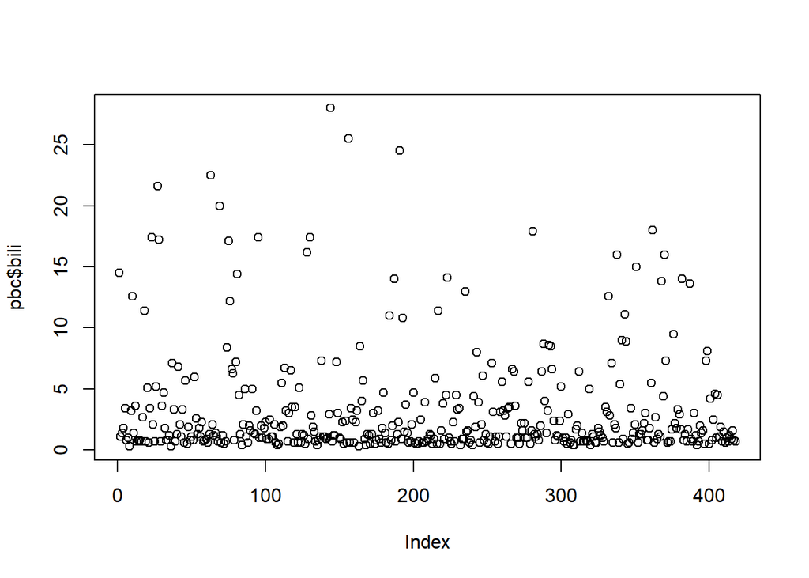

```r
plot(pbc$bili)
```

Basic plot with 2 variables

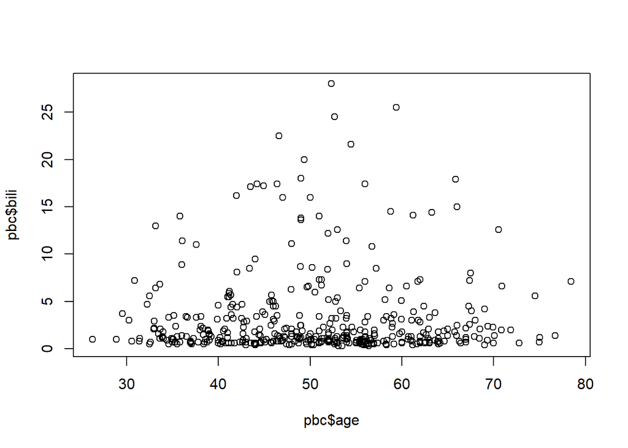

```r
plot(pbc$age, pbc$bili)
```

Basic plot with 2 variables - add axis labels

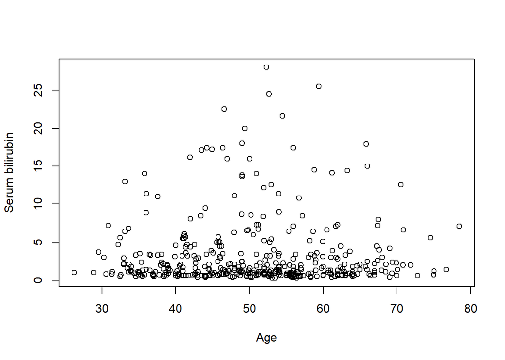

```r
plot(pbc$age, pbc$bili, ylab = "Serum bilirubin", xlab = "Age")
```

Basic plot with 2 variables - add axis labels - change size of axis and labels

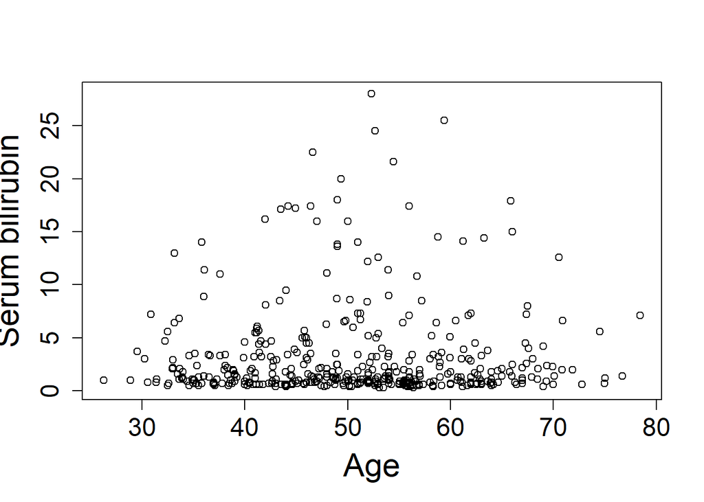

```r
plot(pbc$age, pbc$bili, ylab = "Serum bilirubin", xlab = "Age", cex.axis = 1.5, cex.lab = 1.9)
```

Basic plot with 3 variables - xaxis represents `age`, yaxis represents `serum bilirubin` and colours represent `sex`

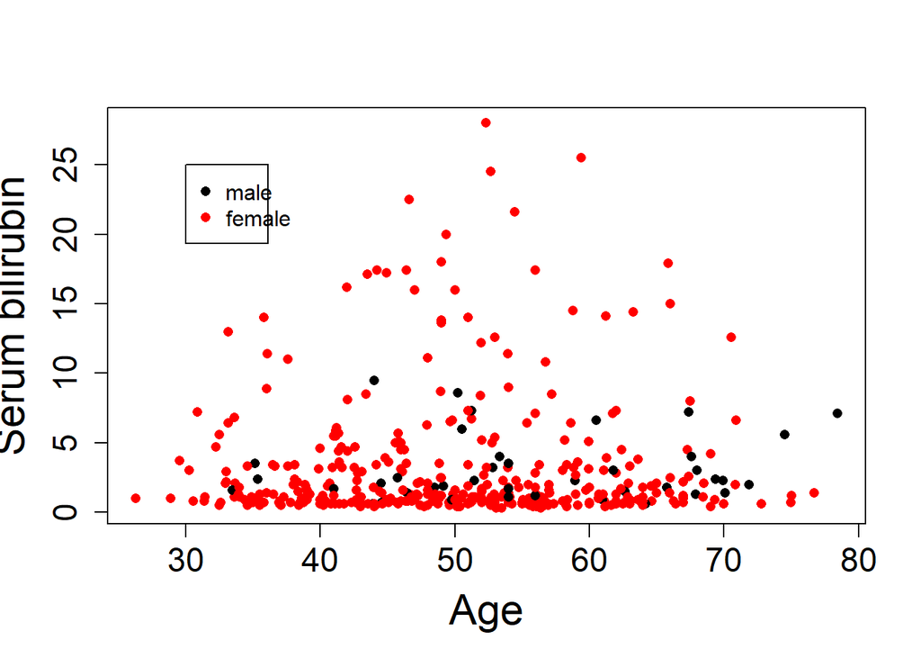

```r
plot(pbc$age, pbc$bili, ylab = "Serum bilirubin", xlab = "Age", cex.axis = 1.5, cex.lab = 1.9, col = pbc$sex, pch = 16)
legend(30, 25, legend = c("male", "female"), col = c(1,2), pch = 16)
```

Histogram

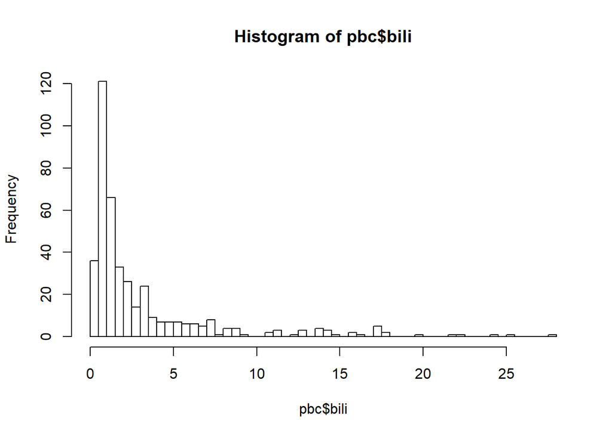

```r
hist(pbc$bili, breaks = 50)
```

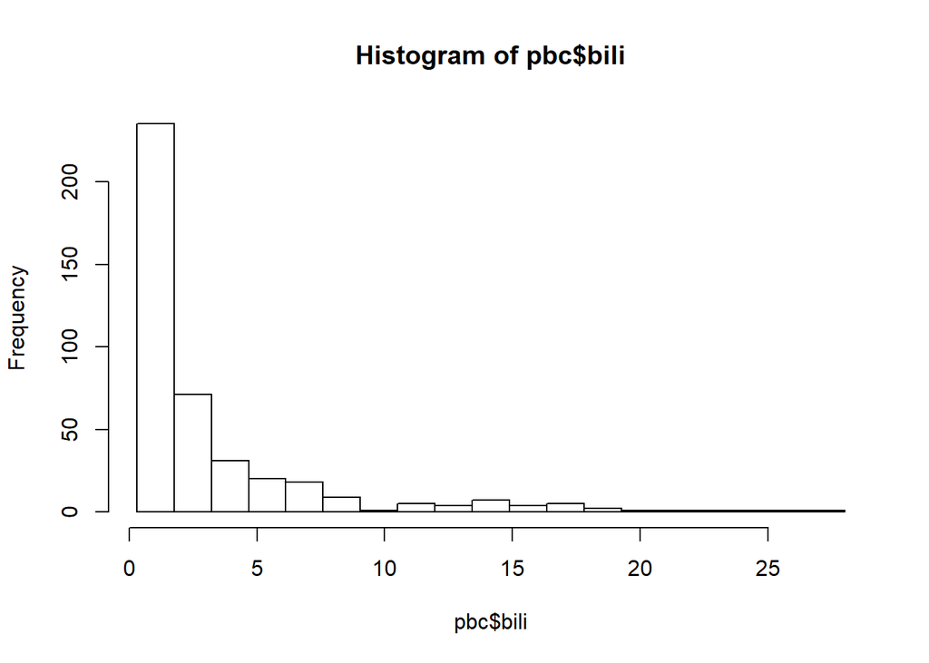

```r
hist(pbc$bili, breaks = seq(min(pbc$bili), max(pbc$bili), length = 20))
```

Multiple panels

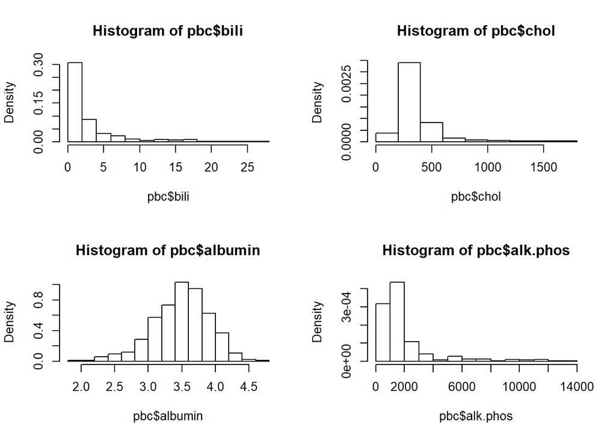

```r
par(mfrow=c(2,2))
hist(pbc$bili, prob=T)
hist(pbc$chol, prob=T)
hist(pbc$albumin, prob=T)
hist(pbc$alk.phos, prob=T)
```

Barchart

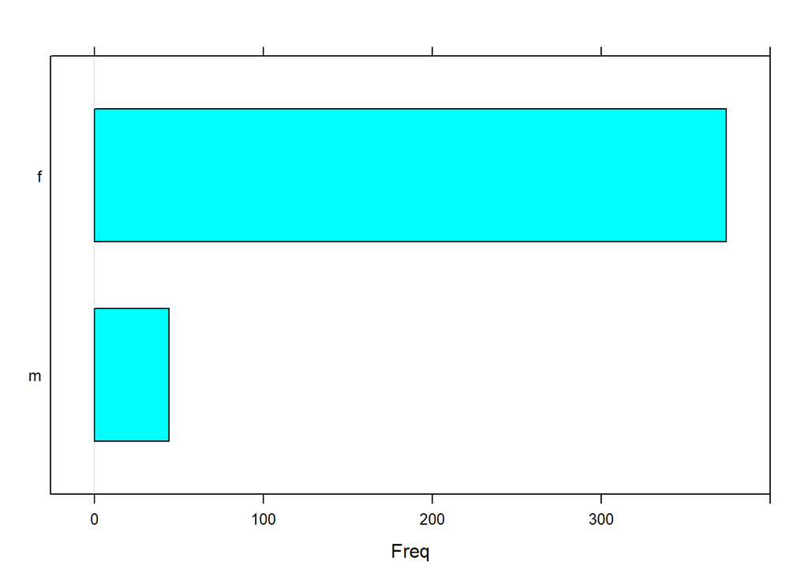

```r
barchart(pbc$sex)
```

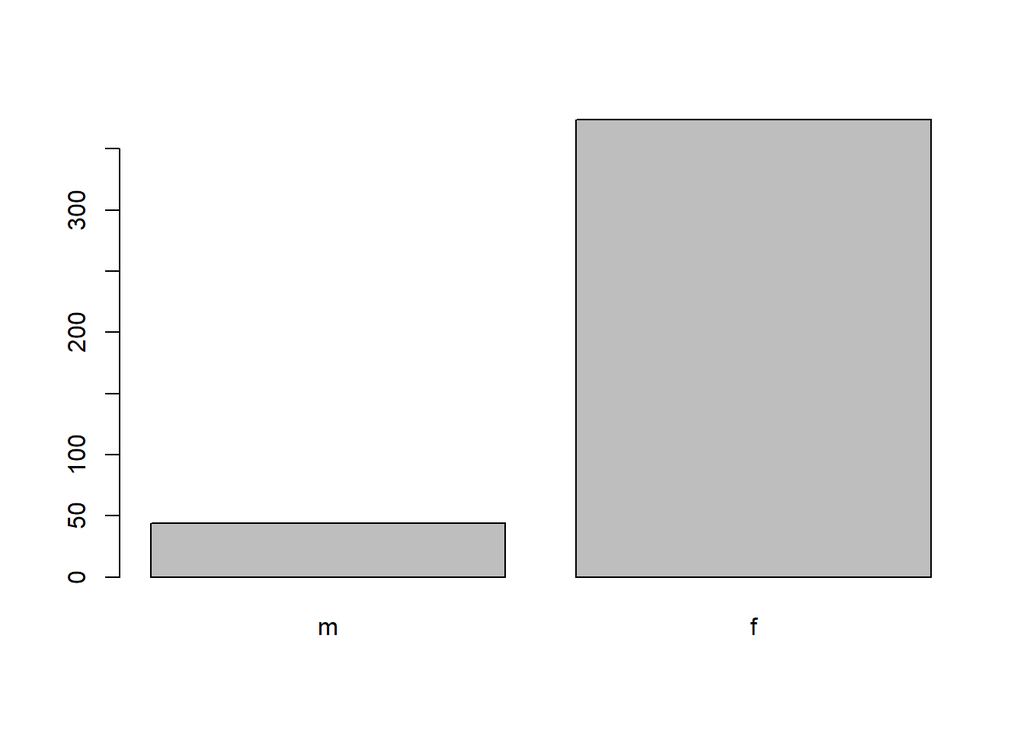

```r
plot(pbc$sex)
```

Boxplot

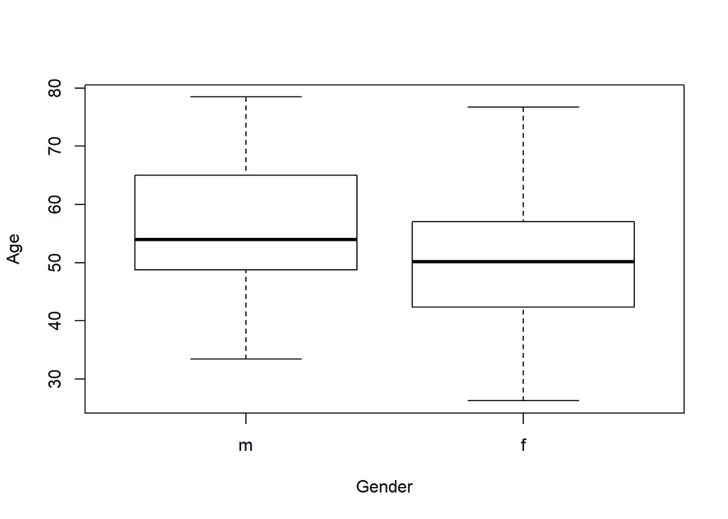

```r
boxplot(pbc$age ~ pbc$sex, ylab = "Age", xlab = "Gender")
```

Multivariate plot

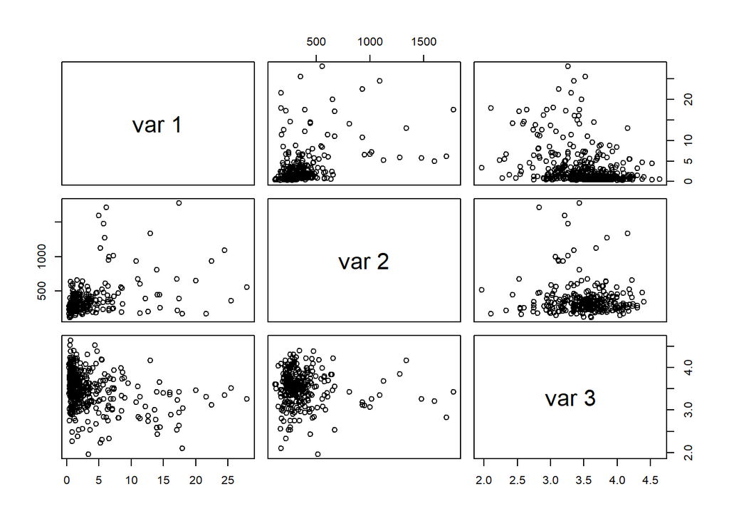

```r
pairs(cbind(pbc$bili, pbc$chol, pbc$albumin))
```

Density plots of `serum bilirubin` per `sex`

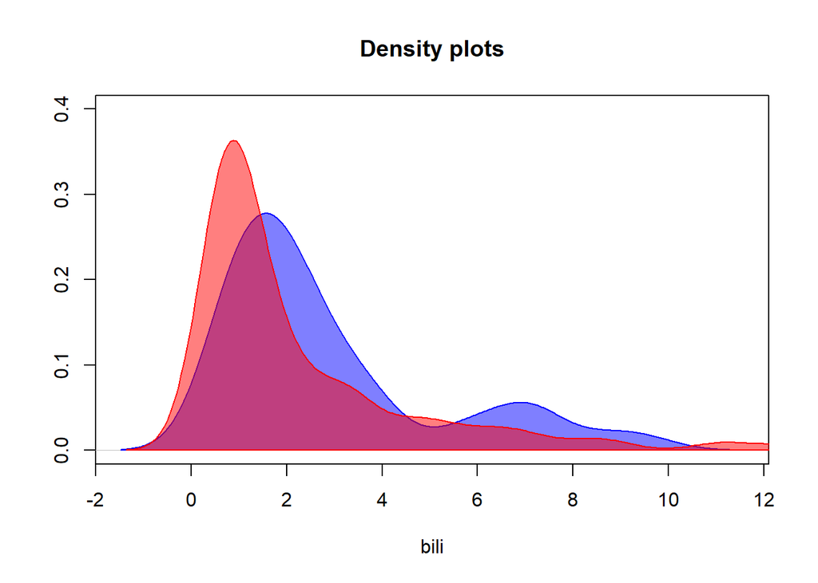

```r
pbc_male_bili <- pbc$bili[pbc$sex == "m"]
pbc_female_bili <- pbc$bili[pbc$sex == "f"]
plot(density(pbc_male_bili), col = rgb(0,0,1,0.5), ylim = c(0,0.40),
     main = "Density plots", xlab = "bili", ylab = "")
polygon(density(pbc_male_bili), col = rgb(0,0,1,0.5), border = "blue")
lines(density(pbc_female_bili), col = rgb(1,0,0,0.5))
polygon(density(pbc_female_bili), col = rgb(1,0,0,0.5), border = "red")
legend(20,0.03, c("male", "female"),
       col = c(rgb(0,0,1,0.5), rgb(1,0,0,0.5)), lty = 1)
```

Lattice family - `serum bilirubin` with `age`

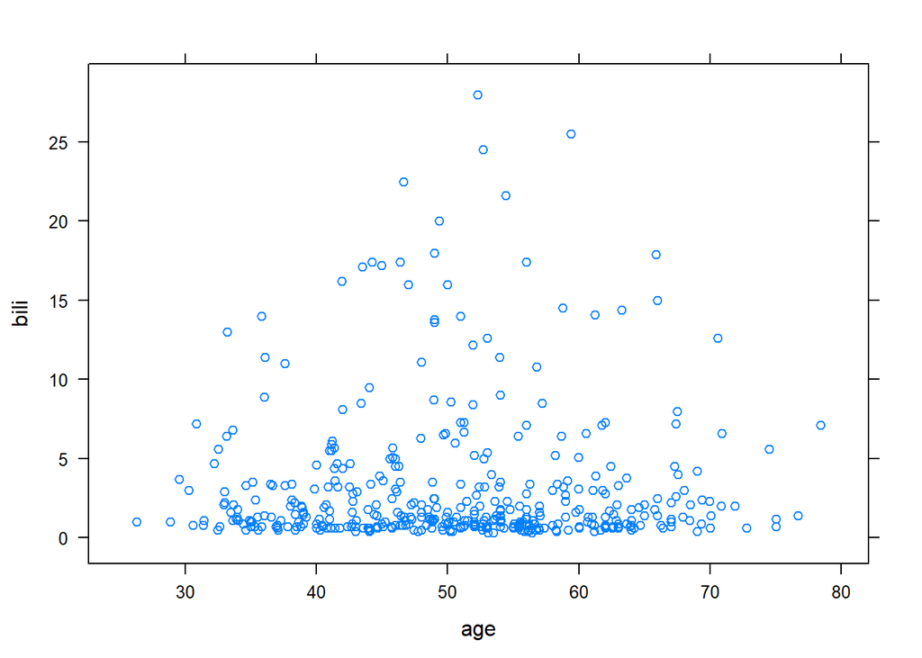

```r
xyplot(bili ~ age, data = pbc, type = "p", lwd = 2)
```

Lattice family - smooth evolution of `serum bilirubin` with `age`

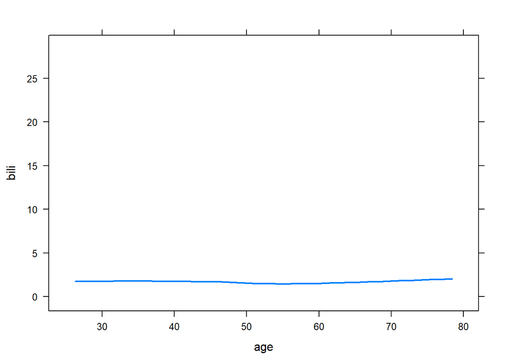

```r
xyplot(bili ~ age, data = pbc, type = "smooth", lwd = 2)
```

Lattice family - smooth evolution of `serum bilirubin` with `age` per `sex`

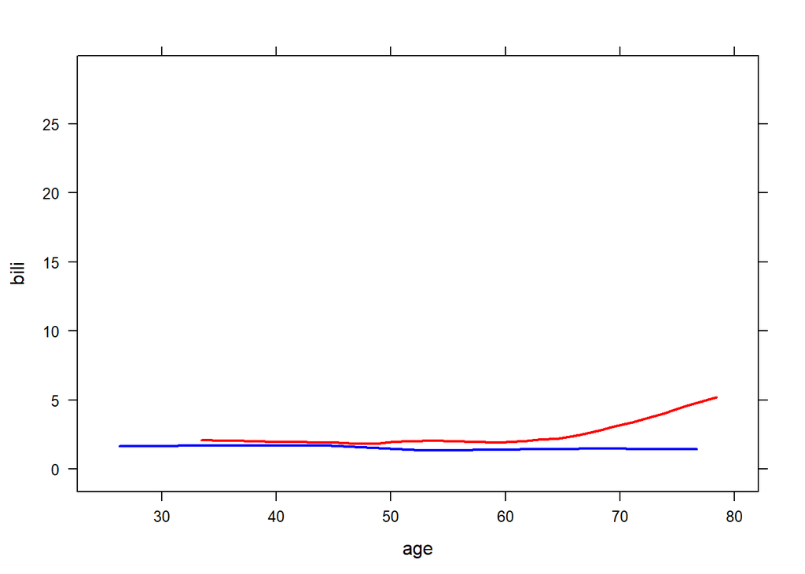

```r
xyplot(bili ~ age, group = sex, data = pbc, type = "smooth", lwd = 2, col = c("red", "blue"))
```

Lattice family - smooth evolution with points of `serum bilirubin` with `age` per `sex`

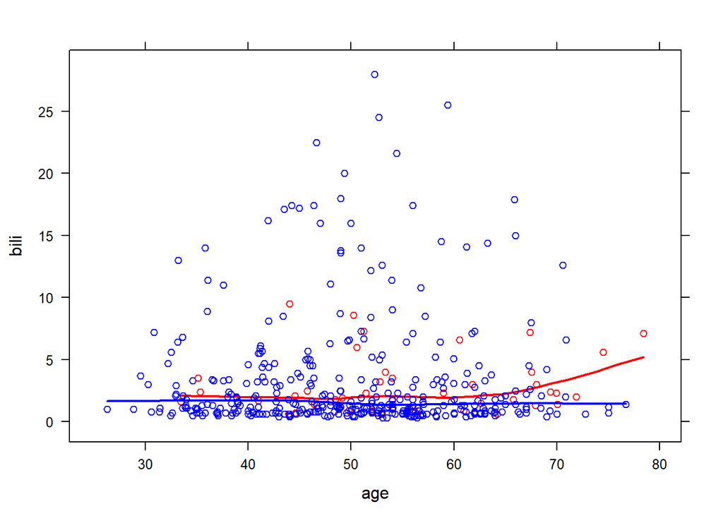

```r
xyplot(bili ~ age, group = sex, data = pbc, type = c("p", "smooth"), lwd = 2, col = c("red", "blue"))
```

Lattice family - smooth evolution with points of `serum bilirubin` with `age` per `sex` (as separate panel)

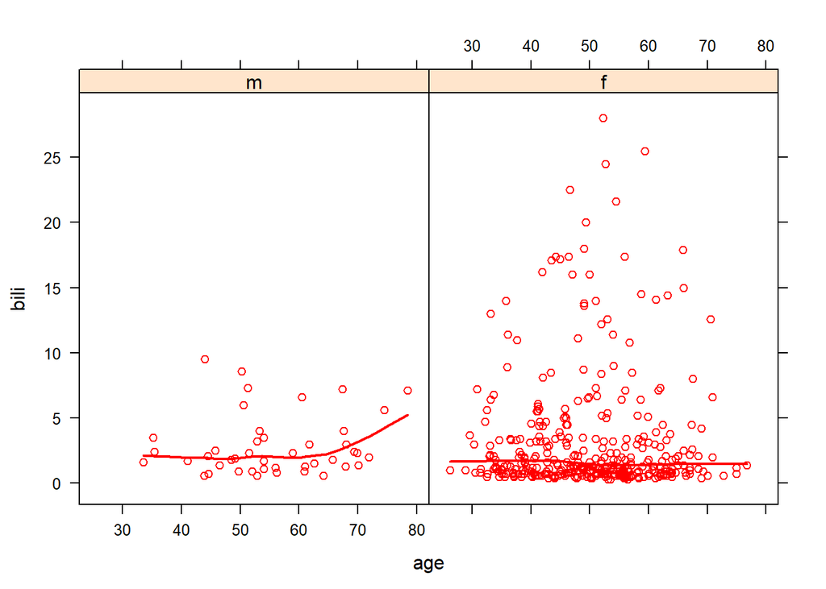

```r
xyplot(bili ~ age | sex, data = pbc, type = c("p", "smooth"), lwd = 2, col = c("red"))
```

Lattice family - smooth evolution with points of `serum bilirubin` with `age` per `status` (as separate panel)

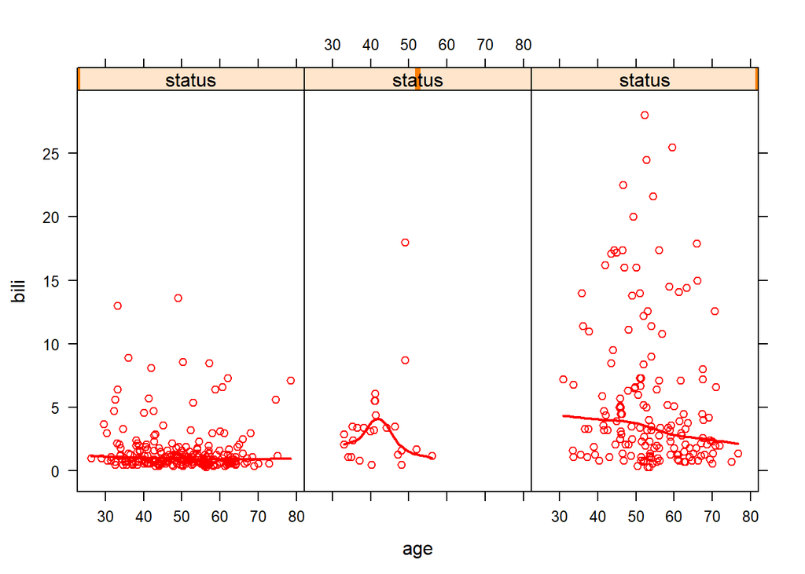

```r
xyplot(bili ~ age | status, data = pbc, type = c("p", "smooth"), lwd = 2, col = c("red"))
```

Lattice family - smooth evolution with points of `serum bilirubin` with `age` per `status` (as separate panel - change layout)

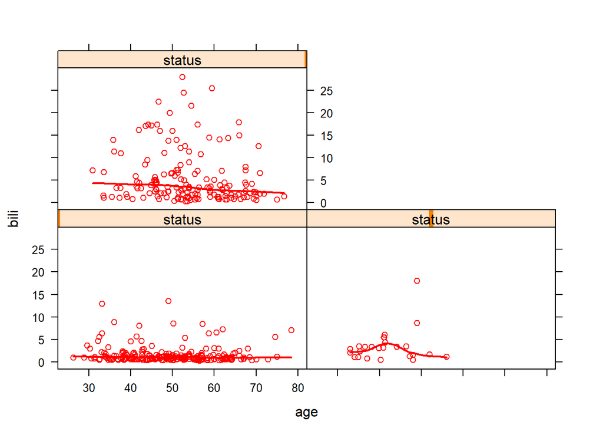

```r
xyplot(bili ~ age | status, data = pbc, type = c("p", "smooth"), lwd = 2, col = c("red"), layout = c(2,2))
```

Lattice family - smooth evolution with points of `serum bilirubin` with `age` per `status` (as separate panel - change layout)  
Add labels for `status`

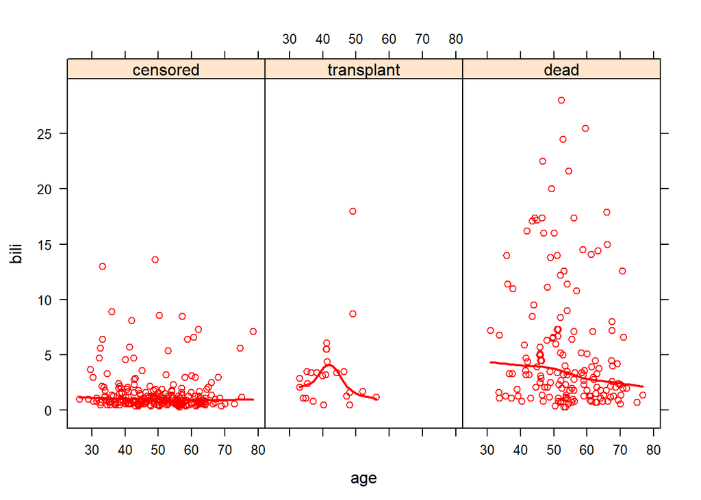

```r
pbc$status <- factor(pbc$status, levels = c(0, 1, 2), labels = c("censored", "transplant", "dead"))
xyplot(bili ~ age | status, data = pbc, type = c("p", "smooth"), lwd = 2, col = c("red"), layout = c(3,1))
```

Lattice family - individual patient plot

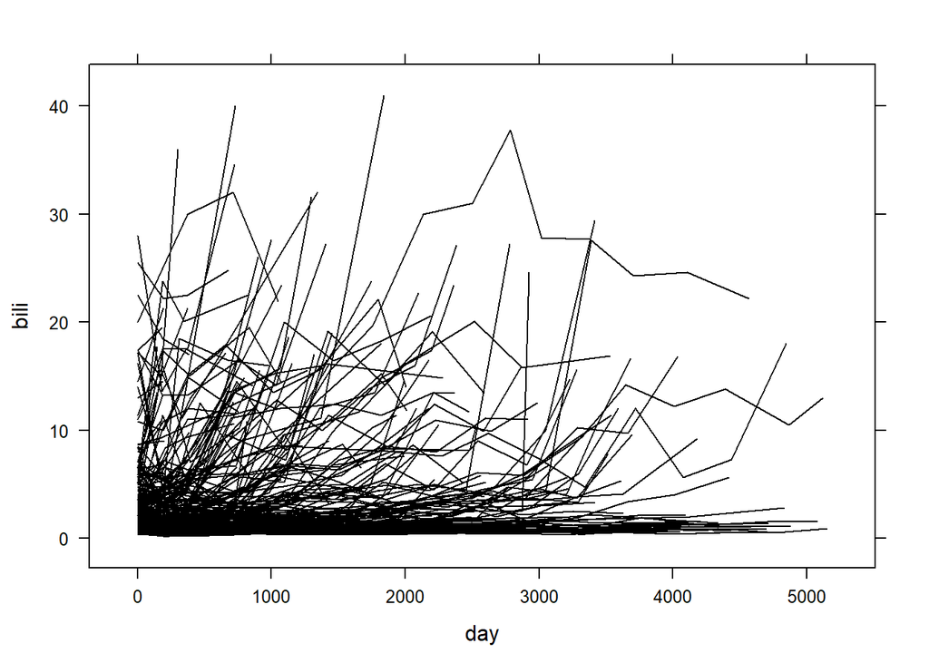

```r
xyplot(bili ~ day, group = id, data = pbcseq, type ="l", col = "black")
```

Lattice family - individual patient plot per `status`

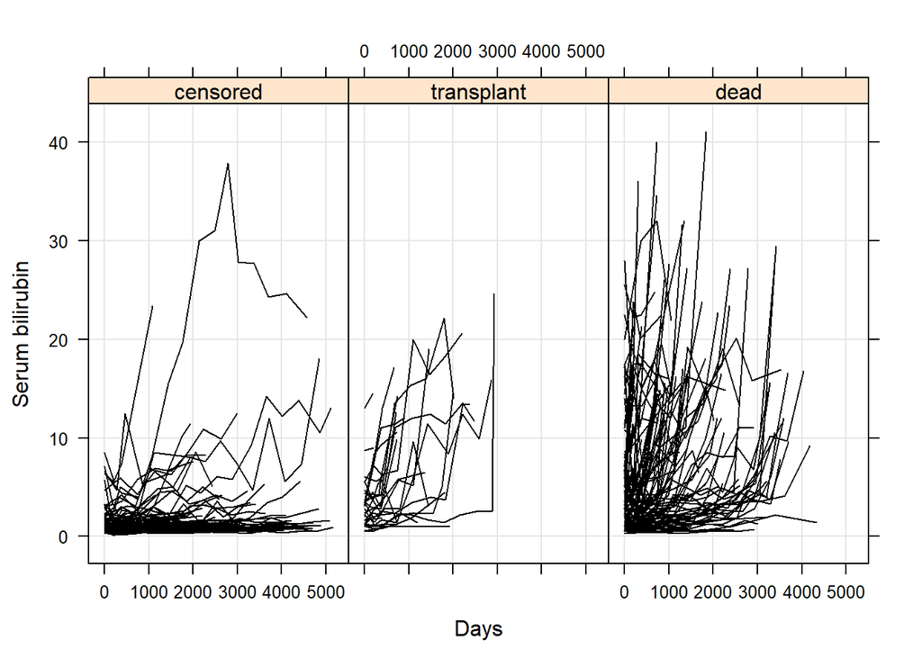

```r
pbcseq$status <- factor(pbcseq$status, levels = c(0, 1, 2), labels = c("censored", "transplant", "dead"))
xyplot(bili ~ day | status, group = id, data = pbcseq, type ="l", col = "black", layout = c(3,1),
       grid = TRUE, xlab = "Days", ylab = "Serum bilirubin")
```

ggplot family - plot `age` with `serum bilirubin`  
Each `sex` has a different colour

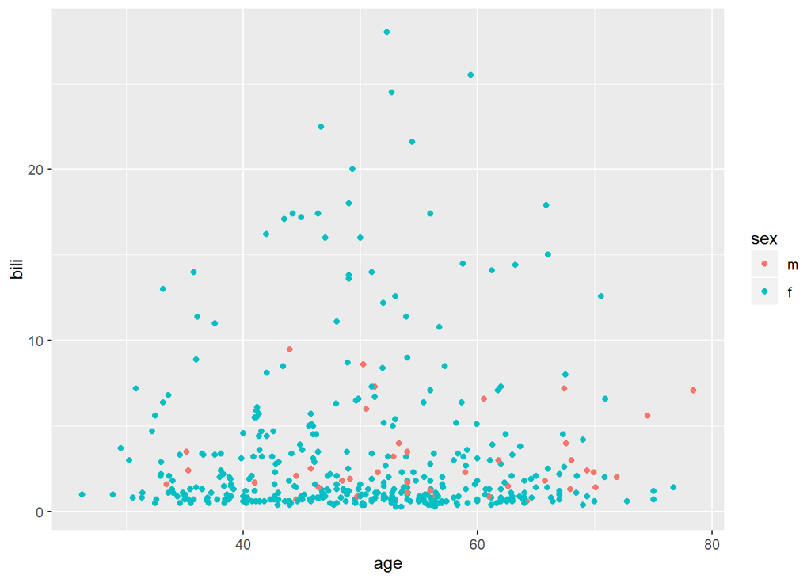

```r
ggplot(pbc, aes(age, bili, colour = sex)) +
  geom_point()
```

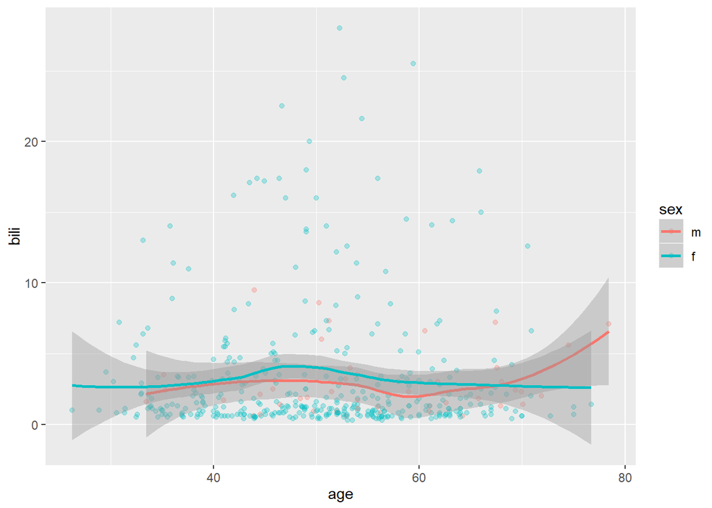

```r
ggplot(pbc, aes(age, bili, colour = sex)) +
geom_point(alpha = 0.3) +
geom_smooth()
```

ggplot family - plot `day` with `serum bilirubin` for patient 93  
A smoothed curve is added in blue

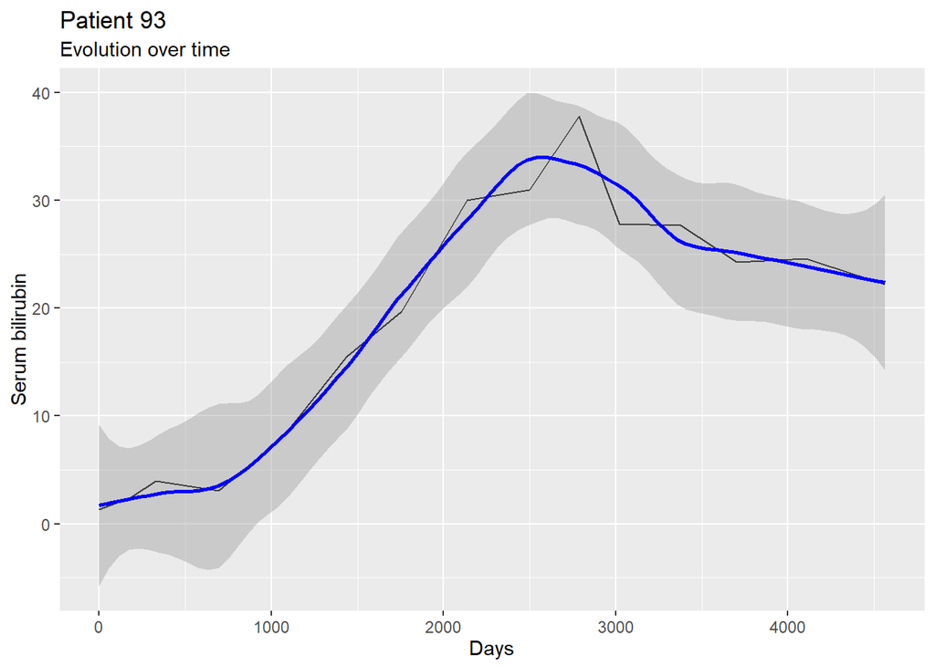

```r
ggplot(pbcseq[pbcseq$id == 93,], aes(day, bili)) +
geom_line() +
geom_smooth(colour = 'blue', span = 0.4) +
labs(title = "Patient 93", subtitle = "Evolution over time",
     y = "Serum bilirubin", x = "Days")
```

ggplot family - plot `serum bilirubin` per `stage`

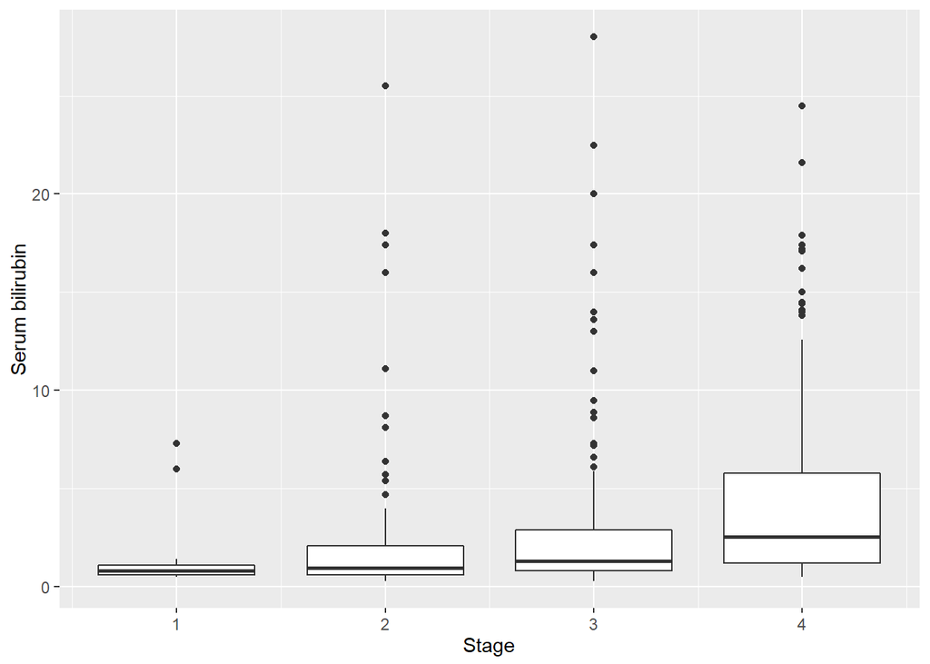

```r
ggplot(pbc, aes(stage, bili, group = stage)) +
geom_boxplot() +
labs(y = "Serum bilirubin", x = "Stage")
```

ggplot family - density plot of `serum bilirubin` per `sex`

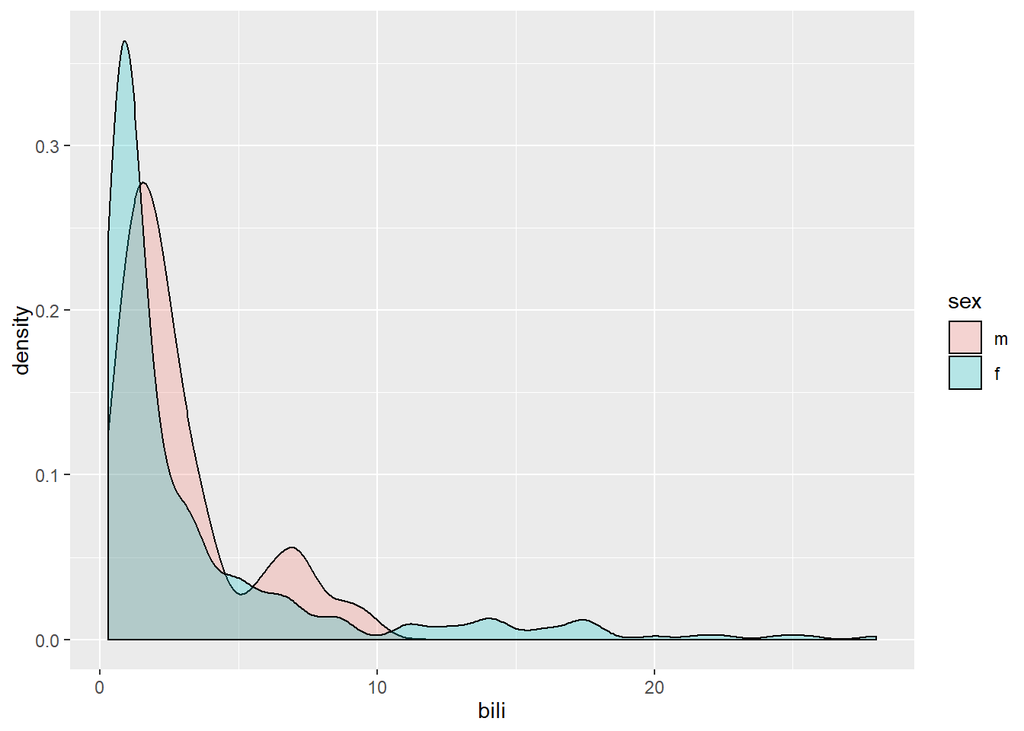

```r
p <- ggplot(pbc, aes(bili, fill = sex)) +
geom_density(alpha = 0.25)
p
```

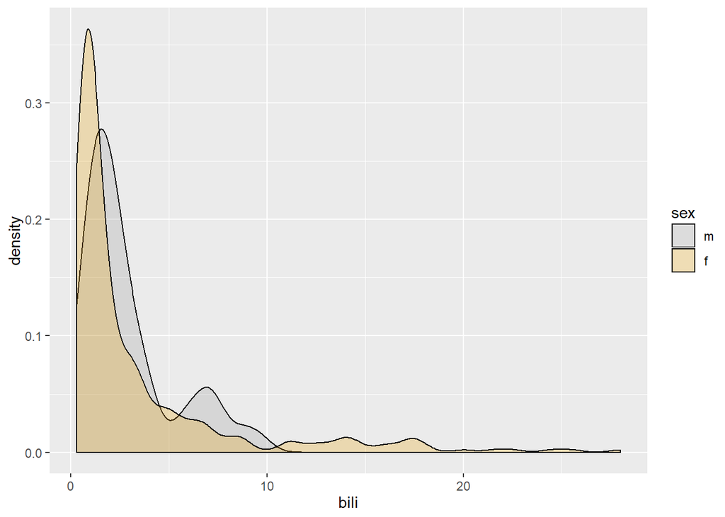

```r
p + scale_fill_manual(values=c("#999999", "#E69F00"))
```

Let’s have some fun

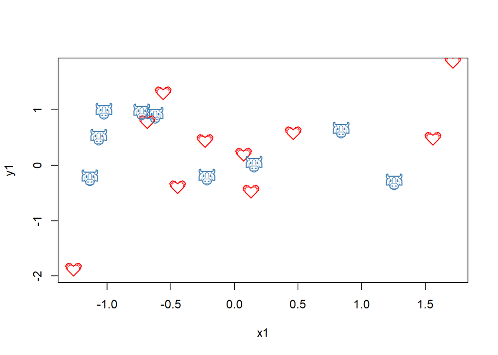

```r
set.seed(123)
x1 <- rnorm(10)
y1 <- rnorm(10)
x2 <- rnorm(10)
y2 <- rnorm(10)
plot(x1, y1, cex=0)
text(x1, y1, labels=emoji('heartbeat'), cex=1.5, col='red', family='EmojiOne')
text(x2, y2, labels=emoji('cow'), cex=1.5, col='steelblue', family='EmojiOne')
```

```r
search_emoji('face')
```

```
##  [1] "slightly_smiling_face"        "upside_down_face"             "money_mouth_face"
##  [4] "nerd_face"                    "clown_face"                   "cowboy_hat_face"
##  [7] "slightly_frowning_face"       "frowning_face"                "tired_face"
## [10] "neutral_face"                 "dizzy_face"                   "drooling_face"
## [13] "lying_face"                   "zipper_mouth_face"            "nauseated_face"
## [16] "sneezing_face"                "face_with_thermometer"        "face_with_head_bandage"
## [19] "crying_cat_face"              "fist_oncoming"                "facepunch"
## [22] "punch"                        "woman_facepalming"            "man_facepalming"
## [25] "pouting_woman"                "person_with_pouting_face"     "fox_face"
## [28] "panda_face"                   "monkey_face"                  "dragon_face"
## [31] "new_moon_with_face"           "full_moon_with_face"          "sun_with_face"
## [34] "first_quarter_moon_with_face" "last_quarter_moon_with_face"  "wind_face"
## [37] "trollface"
```